# Daniel Ferreira dos Santos junior 2019233

# What is the distribution of game categories?

```python
value_counts_df = df['category'].value_counts().reset_index()
value_counts_df.columns = ['category', 'count']
value_counts_df = value_counts_df.sort_values(by='count', ascending=False)
total_count = value_counts_df['count'].sum()
value_counts_df['Percentage'] = (value_counts_df['count'] / total_count) * 100
```

```python
value_counts_df.head(10)
```

|  | category | count | Percentage |
| --- | --- | --- | --- |
| 0 | Wargame,World War II | 449 | 4.301590 |
| 1 | Card Game | 438 | 4.196206 |
| 2 | Abstract Strategy | 284 | 2.720828 |
| 3 | Napoleonic,Wargame | 124 | 1.187967 |
| 4 | Economic | 116 | 1.111324 |
| 5 | Card Game,Fantasy | 110 | 1.053842 |
| 6 | Dice | 107 | 1.025101 |
| 7 | American Civil War,Wargame | 97 | 0.929297 |
| 8 | Modern Warfare,Wargame | 89 | 0.852654 |
| 9 | Party Game | 77 | 0.737689 |

```python
import matplotlib.pyplot as plt
import seaborn as sns
```

# picking only top 10 of the categories

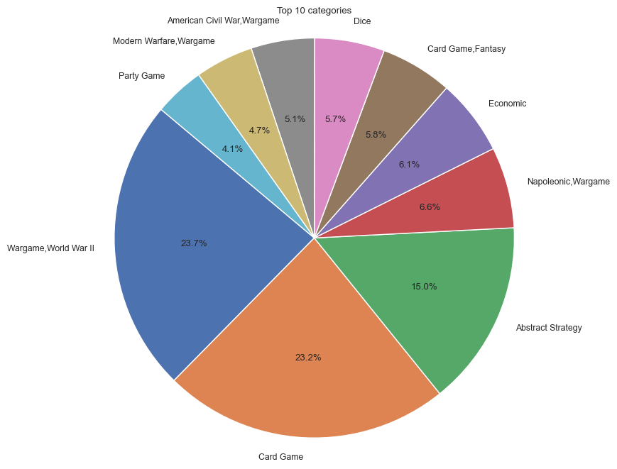

```python
top_10_categories = value_counts_df.head(10)
#pie chart is the easyiest way to see it
plt.figure(figsize=(8, 8))
plt.pie(top_10_categories['count'], labels = top_10_categories['category'], autopct= '%1.1f%%', startangle= 140)
plt.title('Top 10 categories')
plt.axis('equal')
plt.show()
```

The above show the top 10 categories between the whole Dataset which was larger.

# Do older games (1992 and earlier) have a higher MEDIAN “average rating” than newer games (after 1992)?

```python
df_comparison= df[['name', 'year_published', 'average_rating']]
```

```python
df_comparison.head()
```

|  | name | year_published | average_rating |
| --- | --- | --- | --- |
| 0 | Die Macher | 1986 | 7.66508 |
| 1 | Dragonmaster | 1981 | 6.60815 |
| 2 | Samurai | 1998 | 7.44119 |
| 3 | Tal der Könige | 1992 | 6.60675 |
| 4 | Acquire | 1964 | 7.35830 |

older Games(1992 and before) have a higher MEDIAN "average rating" than newer games afterm1992?

```python
# Creating a new column 'category' based on 'year_published'
df_comparison.loc[df_comparison['year_published'] <= 1992, 'category'] = 'Older Games'
df_comparison.loc[df_comparison['year_published'] > 1992, 'category'] = 'Newer Games'
```

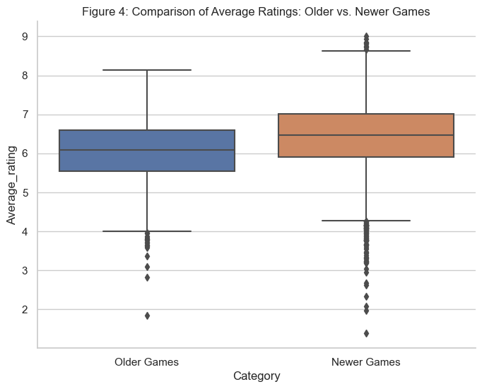

```python
def create_comparison_boxplot(dataframe, x_column, y_column, title):

    # Set the Seaborn style to mimic The Economist's style
    sns.set(style="whitegrid")

    #Creating a boxplot
    plt.figure(figsize=(8, 6))
    ax = sns.boxplot(x=x_column, y=y_column, data=dataframe)
    sns.despine(right=True, top=True)

    #Adding labels and title
    plt.xlabel(x_column.capitalize())
    plt.ylabel(y_column.capitalize())
    plt.title(title)
    plt.show()
create_comparison_boxplot(df_comparison, 'category', 'average_rating', 'Figure 4: Comparison of Average Ratings: Older vs. Newer Games')
```

```python
df_comparison.head()
```

|  | name | year_published | average_rating | category |
| --- | --- | --- | --- | --- |
| 0 | Die Macher | 1986 | 7.66508 | Older Games |
| 1 | Dragonmaster | 1981 | 6.60815 | Older Games |
| 2 | Samurai | 1998 | 7.44119 | Newer Games |
| 3 | Tal der Könige | 1992 | 6.60675 | Older Games |
| 4 | Acquire | 1964 | 7.35830 | Older Games |

```python
import scipy.stats as stats
import numpy as np
import pandas as pd
```

```python
# two groups for the Mann-Whitney U test
older_games_ratings = df_comparison[df_comparison['category'] == 'Older Games']['average_rating']
newer_games_ratings = df_comparison[df_comparison['category'] == 'Newer Games']['average_rating']
```

```python
# Making the size of the smaller group
min_group_size = min(len(older_games_ratings), len(newer_games_ratings))

# Subsampling the larger group to have the same size as the smaller group
np.random.seed(42)
if len(older_games_ratings) > len(newer_games_ratings):
    subsample_old = older_games_ratings.sample(n=min_group_size, replace=False)
    subsample_new = newer_games_ratings
else:
    subsample_old = older_games_ratings
    subsample_new = newer_games_ratings.sample(n=min_group_size, replace=False)
```

```python
# Mann-Whitney U test
u_statistic, p_value = stats.mannwhitneyu(subsample_old, subsample_new, alternative='greater')
```

```python
#summary table
results_summary = pd.DataFrame({
    'Category': ['Older Games', 'Newer Games'],
    'Sample Size': [len(subsample_old), len(subsample_new)],
    'U Statistic': [u_statistic, None],
    'P-Value': [p_value, None]
})
results_summary
```

|  | Category | Sample Size | U Statistic | P-Value |
| --- | --- | --- | --- | --- |
| 0 | Older Games | 1934 | 1332223.5 | 1.0 |
| 1 | Newer Games | 1934 | NaN | NaN |

After a Mann-Whitney U test to test the following hypotheses:

H0: There is no significant difference in the median "average rating" between older games (published in 1992 or earlier) and newer games (published after 1992).

H1: Older games (published in 1992 or earlier) have a higher median "average rating" than newer games (published after 1992).

The choice of the Mann-Whitney U test was appropriate for this hypothesis test due to its non-parametric nature, making it robust against distributional assumptions. Due to the disparity in the sizes of the two samples, 1,934 observations in the "older_games_ratings" group and 8,598 in the "newer_games_ratings" group we did subsampling which involves taking a smaller sample from newer_games_rAatings, without replacement, to obtain a distribution of test statistics (such as U-statistics) or p-values, This helped in reducing potential for bias in the Mann-Whitney U test results resulting from imbalanced sample sizes, the larger group may have more diverse characteristics, and the smaller group may be less representative. By subsampling, you can make the groups more comparable, potentially reducing the impact of these biases.

Based on the Table , the p-value(1.0) exceeded our chosen significance level (0.05). This implies that the data did not provide strong evidence against the null hypothesis. Thus, there is insufficient statistical evidence to conclude that older games (published in 1992 or earlier) have a higher median "average rating" than newer games (published after 1992).

# What are the 5 most common “mechanics” in the dataset?

```python
df_mechanic = df ['mechanic'].value_counts().reset_index()
df_mechanic.columns = ['Mechanic', 'Count']
```

```python
#reindex the df
df_mechanic = df_mechanic.reset_index(drop= True)
df_mechanic = df_mechanic.sort_values(by='Count', ascending=False)
```

```python
df_mechanic.head()
```

|  | Mechanic | Count |
| --- | --- | --- |
| 0 | Hex-and-Counter | 523 |
| 1 | Hand Management | 297 |
| 2 | Dice Rolling | 222 |
| 3 | Roll / Spin and Move | 199 |
| 4 | Tile Placement | 170 |